# Association Mining - A Basket Analysis of Cincinnati Zoo Eateries

# Introduction

Association mining is an unsupervised machine learning method for discovering hidden patterns and relations. It’s a study of what goes with what. Having it’s history in the retail sector, it’s extensively used in market basket analysis of customer transactions. The recommendation systems of [Amazon](http://rejoiner.com/resources/amazon-recommendations-secret-selling-online/), [Target](https://www.forbes.com/sites/kashmirhill/2012/02/16/how-target-figured-out-a-teen-girl-was-pregnant-before-her-father-did/#60d85b5a6668) and [Spotify](https://medium.com/@ericboam/i-decoded-the-spotify-recommendation-algorithm-heres-what-i-found-4b0f3654035b) are powered by association mining. They are employed in many other applications today including web-usage mining like Youtube and Facebok, and even in the field of bioinformatics.

The Cincinnati Zoo, opened to the public in 1875, is the second oldest zoo in the nation. Famous for Harambe and Fiona, it serves over a million visitors each year. The data that we will be looking at has all purchase transactions of the eateries of the zoo. We will be using the `Apriori algorithm` to look for associations in customer buying behaviors.

# Required Packages

The packages listed below in the code chunk are required to replicate this document.

```r
library(tidyverse) # The gasoline for the CaR
library(arules) # Association rules algorithm
library(arulesViz) # Visualizing associations
library(DT) # Print HTML Tables
library(knitr) # Generating HTML document
library(rmdformats) # Document theme

# Globally controlling code blocks
opts_chunk$set(message = FALSE,
               warning = FALSE,
               fig.align = "center",
               fig.height = 4,
               fig.width = 6)

# DT::datatable parameters
options(DT.options = list(paging = FALSE, # disable pagination
                          scrollY = "200px", # enable vertical scrolling
                          scrollX = TRUE, # enable horizontal scrolling
                          scrollCollapse = TRUE,
                          ordering = FALSE, # disable sorting data
                          dom = "t"))  # display just the table
```

# Data Exploration

The data has 19076 rows and 119 columns. Each row represents a purchase and the columns of the data are the items a customer can buy. The items purchased during the transactio is marked 1 for the column and all other entries are zero. A sample of the data is printed below.

```r
data <- read_csv("files/cinci_zoo_purchases.csv")

# There's a "Food" at the end of each column name. Removing it
colnames(data) <- gsub("Food", "", colnames(data))

# Dropping the transaction ID
data <- data[, -1]

# Find out elements that are not equal to 0 or 1 and change them to 1.
other_vals <- which(!(as.matrix(data) == 1 | as.matrix(data) == 0), arr.ind = TRUE )
data[other_vals] <- 1

data %>% tail(5) %>% datatable(caption = "Sample of the purchase data")
```

|  | Add Cheese | Beer | Bottled Water | Bowl of Chili w/Cheese | Bowl of Chili | Brat/Sausage | Bud Light | Burger Basket | Burger | Buy One Get One Ice Cream Cone | Capri Sun | Caramel Apple w/Topping | Caramel Apple | Cheese Coney | Cheese Fries Basket | Cheeseburger Basket | Cheeseburger | Chicken Nugget Basket | Chicken Nuggets | Chicken Tender Basket | Chicken Tenders | Chili Cheese Sandwich | Chili | Chips | Coffee | Coney | Cookie | Cotton Candy | Double Cheeseburger | … |
| --- | --- | --- | --- | --- | --- | --- | --- | --- | --- | --- | --- | --- | --- | --- | --- | --- | --- | --- | --- | --- | --- | --- | --- | --- | --- | --- | --- | --- | --- | --- |
| 1 | 0 | 0 | 0 | 0 | 0 | 0 | 0 | 0 | 0 | 0 | 0 | 0 | 0 | 0 | 0 | 0 | 0 | 0 | 0 | 0 | 0 | 0 | 0 | 0 | 0 | 0 | 0 | 0 | 0 | … |
| 2 | 0 | 0 | 0 | 0 | 0 | 0 | 0 | 0 | 0 | 0 | 0 | 0 | 0 | 0 | 0 | 0 | 0 | 0 | 0 | 0 | 0 | 0 | 0 | 0 | 0 | 0 | 0 | 0 | 0 | … |
| 3 | 0 | 0 | 0 | 0 | 0 | 0 | 0 | 0 | 0 | 0 | 0 | 0 | 0 | 0 | 0 | 0 | 0 | 0 | 0 | 0 | 0 | 0 | 0 | 0 | 0 | 0 | 0 | 0 | 0 | … |
| 4 | 0 | 0 | 0 | 0 | 0 | 0 | 0 | 0 | 0 | 0 | 0 | 0 | 0 | 0 | 0 | 1 | 0 | 0 | 0 | 0 | 0 | 0 | 0 | 0 | 0 | 0 | 0 | 0 | 0 | … |
| 5 | 0 | 0 | 0 | 0 | 0 | 0 | 0 | 0 | 0 | 0 | 0 | 0 | 0 | 0 | 0 | 0 | 0 | 0 | 0 | 0 | 0 | 0 | 0 | 0 | 0 | 0 | 0 | 0 | 0 | … |

A chart of top selling items is presented below.

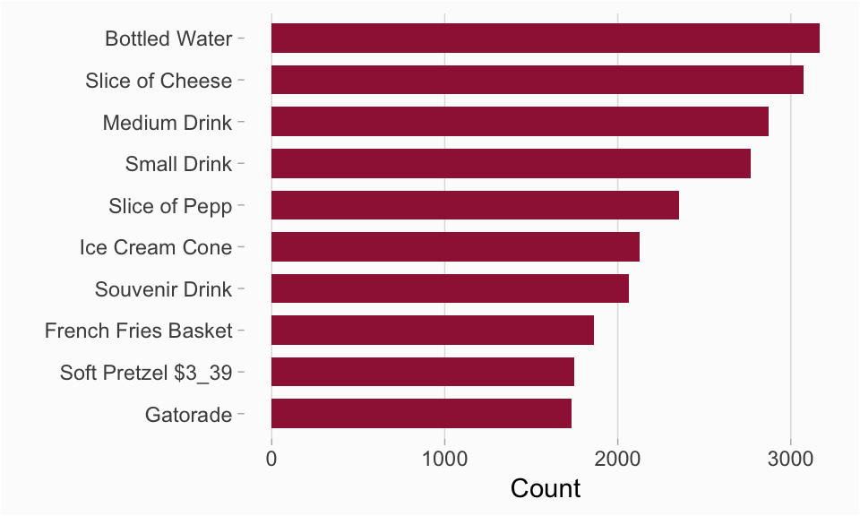

```r
theme_hn <- theme_light() +  theme(panel.grid.minor.x = element_blank(),
                                   panel.grid.major.y = element_blank(),
                                   panel.background = element_rect(fill = "#fcfcfc"),
                                   plot.background = element_rect(fill = "#fcfcfc"),
                                   panel.border = element_blank())

data %>% colSums() %>% as.data.frame() %>% rownames_to_column("Items") %>%
  rename("Count" = ".") %>% arrange(desc(Count)) %>% head(10) %>%
  ggplot(aes(reorder(Items, Count), Count)) + geom_col(fill = "#9f2142", width = 0.7) +
  coord_flip() + xlab("") + theme_hn
```

All the `0`’s in the dataset do not hold information and therefore, the data is converted into a sparse matrix where the zeroes are not recorded. The R implementation of the Apriori model that we will be applying expects the data in this format. The sparse version of the same five rows from the above table are printed again.

```r
# Change to sparse version
data <- as(as.matrix(data), "transactions")

as(data, "data.frame") %>% tail(5) %>% datatable(caption = "Sparse version of the data")
```

|  | items |
| --- | --- |
| 19072 | {Souvenir Refill} |
| 19073 | {Souvenir Mountain Dew Refill} |
| 19074 | {Souvenir Refill} |
| 19075 | {Cheeseburger Basket,Souvenir Drink} |
| 19076 | {Hot Chocolate Souvenir Refill,Hot Chocolate Souvenir} |

# Association Basics

In association mining, the observed patterns are expressed in terms of `rules.` A rule is a set of events occurring together frequently. In our case, it’s a notation of items bought together. If items on the Left-Hand-Side are purchased, then there is a chance that the items on the Right-Hand-Side would also be bought along.

$$\{item_a\ item_b\} => \{item_x \ item_y\}$$

In theory, if all items are considered, there could be exponentially many rules. Measuring the strength of each rule becomes essential to keep that in check. There are three main parameters.

- `Support` - Percentage of purchases that contain all of the items on the LHS and RHS. It’s a measure of how frequently the items are bought together.

$$\frac{number\ of\ purchases\ with\ items\ \{a, b, x, y\}}{number\ of\ purchases}$$

- `Confidence` - This measures the reliability of the rule - how often it was found to be true. It’s the conditional probability of items on the RHS purchased, given items on the LHS were also purchased.

$$\frac{number\ of\ purchases\ with\ items\ \{a, b, x, y\}}{number\ of\ purchases\ with\ items\ \{a, b\}}$$

- `Lift` - This is a measure of independance of the events on the LHS and RHS. A value equal to 1 indicates they are completely independant, while a value greater than 1 indicates the opposite. A value less than 1, however, means that the items are substitutes; that is, items on the LHS have a negative effect on the purchase of items on the RHS.

$$\frac{number\ of\ purchases\ with\ items\ \{a, b, x, y\}}{number\ of\ purchases\ with\ items\ \{a, b\} * number\ of\ purchases\ with\ items\ \{x, y\}}$$

# Preliminary Analysis

Apriori algorithm is the most commonly used algorithm for assotiation mining we apply it to the data, setting the minimum support and confidence at 0.003 and 0.5 respectievly. This means that only items that have been purchased at least 3 times every thousand purchases are considered for analysis.

```r
basket_rules <- apriori(data, parameter = list(sup = 0.003, conf = 0.5,
                                               target = "rules"),
                        control = list(verbose = FALSE)) # Prevent output print
```

The algorithm comes up with 42 rules. They are printed in the decreasing order of count.

```r
as(basket_rules, "data.frame") %>% arrange(desc(count)) %>%
  mutate(support = round(support, 4),
         confidence = round(confidence, 4),
         lift = round(lift, 4)) %>%
  datatable(caption = "Rules of Association",
            options = list(ordering = TRUE))
```

|  | rules | support | confidence | lift | count |
| --- | --- | --- | --- | --- | --- |
| 1 | {Topping} =&gt; {Ice Cream Cone} | 0.0286 | 0.9982 | 8.9479 | 545 |
| 2 | {Add Cheese} =&gt; {Soft Pretzel $3_39} | 0.0191 | 0.6966 | 7.6016 | 365 |
| 3 | {Chicken Tenders} =&gt; {French Fries Basket} | 0.0173 | 0.7586 | 7.772 | 330 |
| 4 | {Cheeseburger} =&gt; {French Fries Basket} | 0.0169 | 0.7931 | 8.1253 | 322 |
| 5 | {Hot Chocolate Souvenir Refill} =&gt; {Hot Chocolate Souvenir} | 0.015 | 0.5597 | 13.181 | 286 |
| 6 | {Medium Drink,Slice of Pepp} =&gt; {Slice of Cheese} | 0.0136 | 0.5274 | 3.2749 | 260 |
| 7 | {Bottled Water,Slice of Pepp} =&gt; {Slice of Cheese} | 0.0107 | 0.5152 | 3.1989 | 204 |
| 8 | {Gatorade,Slice of Pepp} =&gt; {Slice of Cheese} | 0.0101 | 0.5831 | 3.6207 | 193 |
| 9 | {Chips,Slice of Pepp} =&gt; {Slice of Cheese} | 0.0083 | 0.5809 | 3.6071 | 158 |
| 10 | {Slice of Pepp,Souvenir Drink} =&gt; {Slice of Cheese} | 0.0081 | 0.5032 | 3.125 | 155 |

[output cut: 32 more lines]

The support of 0.0286 for the first rule indicates that ~3% of the purchases included Topping and Ice Cream Cone together. An extremly high confidence of 0.998 indicates that 99.8% of the time someone ordered Toppings, an Ice Cream Cone was also purchased along with it. Couldn’t tell what the other 0.2% ordered toppings for. A lift much larger than 1 indicates positive correlation.

All the rules are visualized through the interactive chart below.

```r
plot(basket_rules, method = "graph",  engine = "htmlwidget")
```

[interactive chart not shown]

# Shiny App

[interactive chart not shown]

Harish M